# Rmarkdown

# Example

We have data about 53940 diamonds. Only 126 are larger than 2.5 carats. The distribution of the remainder is shown below:

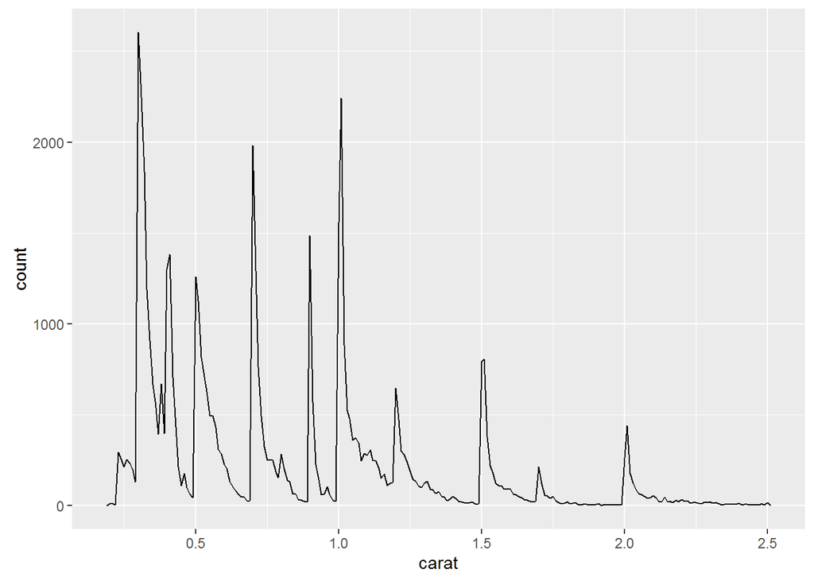

# Structure

- YAML header : the structure surrounded by — — —
- Chunks : the structure surrounded by ```
- Text

# Code execution

Ctrl+shit+Enter on RStudio in Windows

# Formatting

## Text formatting

*italic* or *italic* **bold** **bold** `code` superscript<sup>2</sup> and subscript<sub>2</sub>

# 1st Level Header

## 2nd Level Header

### 3rd Level Header

## Lists

- Bulleted list item 1
- Item 2
  - Item 2a
  - Item 2b
1. Numbered list item 1
2. Item 2. The numbers are incremented automatically in the output.

## Links and images

http://example.com

## Tables

| First Header | Second Header |
| --- | --- |
| Content Cell | Content Cell |
| Content Cell | Content Cell |

# Code chunk

- Adding a code chunk : Ctrl+alt+I

## Code chunk options

- eval=FALSE : does not run the code
- include=FALSE : run the code but does not show the code and the results
- echo=FALSE : prevents the code to appear in the output document
- message=FALSE : does not show messages
- warning=FALSE : does not show warnings
- results=‘hide’ : hide results
- fig.show=‘hide’ : hide plots
- cache = TRUE : store the results of the chunk and rerun the chunk in the next execution only if the code has been changed.

## Table display

Use of kable() function from knitr package allows to obtain nicer outputs.

```r
knitr::kable(
  mtcars[1:5, ],
  caption = "A knitr kable."
)
```

A knitr kable.

|  | mpg | cyl | disp | hp | drat | wt | qsec | vs | am | gear | carb |
| --- | --- | --- | --- | --- | --- | --- | --- | --- | --- | --- | --- |
| Mazda RX4 | 21.0 | 6 | 160 | 110 | 3.90 | 2.620 | 16.46 | 0 | 1 | 4 | 4 |
| Mazda RX4 Wag | 21.0 | 6 | 160 | 110 | 3.90 | 2.875 | 17.02 | 0 | 1 | 4 | 4 |
| Datsun 710 | 22.8 | 4 | 108 | 93 | 3.85 | 2.320 | 18.61 | 1 | 1 | 4 | 1 |
| Hornet 4 Drive | 21.4 | 6 | 258 | 110 | 3.08 | 3.215 | 19.44 | 1 | 0 | 3 | 1 |
| Hornet Sportabout | 18.7 | 8 | 360 | 175 | 3.15 | 3.440 | 17.02 | 0 | 0 | 3 | 2 |

## Global options

To st global options for chunk, use opts_cunk$set() function as shown in the example.

```r
knitr::opts_chunk$set(
  echo = FALSE
)
```

# Inline code

You can use mark to display computed numbers directly in the text. Like this: 53940

## Formats

If inserting numbers in the text, format can be changed as follows for large numbers.

```
## [1] "3,452,345"
```

```
## [1] "0.12"
```

# YAML header

Parameters can be set directly in the Rmarkdown header.

For example in this document, header was set as : my_class: “suv” .

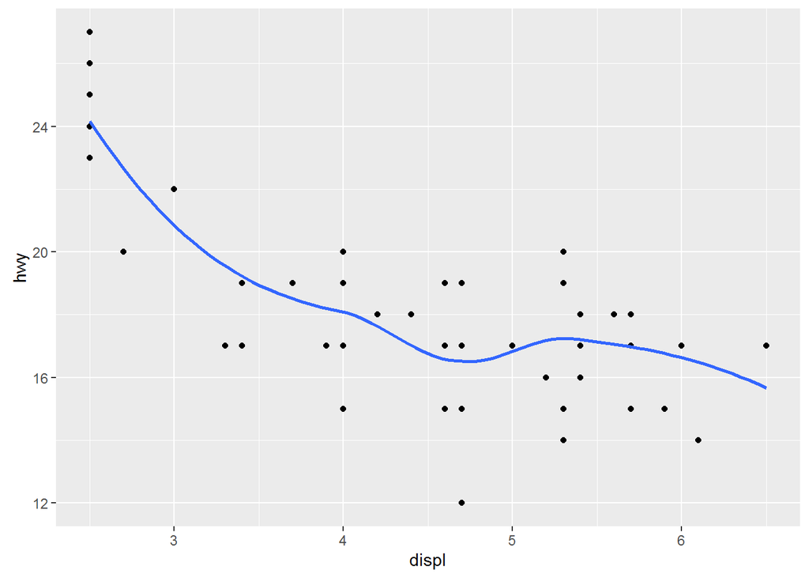